# Diversity of fish and vulnerable species in Marine World Heritage Sites based on OBIS data

This notebook explores species diversity in Marine World Heritage Sites using OBIS data. This is work in progress.

## How to use this notebook

Optionally remove the following cache files before running the notebook:

- `data/occurrence.Rdata`: occurrences by site
- `data/bold.Rdata`: statistics on barcode sequences in BOLD for all fish species

If necessary, adjust fish and coral taxonomy below:

```r
fish_classes <- c("Actinopteri", "Cephalaspidomorphi", "Myxini", "Petromyzonti", "Elasmobranchii", "Holocephali", "Coelacanthi", "Chondrostei", "Teleostei")
fish_orders <- c("Cetomimiformes", "Gasterosteiformes", "Scorpaeniformes", "Stephanoberyciformes")
coral_classes <- c("Anthozoa")
not_coral_orders <- c("Penicillaria", "Spirularia", "Actiniaria")
```

## Other resources

A separate repository has been set up for compiling species list based on existing publications, see https://github.com/iobis/mwhs-species-lists.

## Dependencies

```r
library(dplyr)
library(caspr)
library(rredlist)
library(knitr)
library(ggplot2)
library(sf)
library(mapview)
library(concaveman)
library(sfheaders)
library(purrr)
library(robis)
library(stringr)
library(ftplottools)
library(ggrepel)
```

## Compiling a list of all WoRMS species including IUCN Red List category and BOLD barcode statistics

First read all accepted WoRMS species. As it’s not possible to get a full species list from the WoRMS or GBIF web services, I’m reading directly from an export provided by the WoRMS team. The list of fish classes and orders above is used to determine if species are fish or not.

```r
worms <- read.csv("data/taxon.txt", sep = "\t", quote = "") %>%
  as_tibble() %>%
  filter(taxonRank == "Species" & taxonomicStatus == "accepted") %>%
  select(taxonID, scientificName, kingdom, phylum, class, order, family, genus) %>%
  distinct() %>%
  mutate(is_fish = class %in% fish_classes | order %in% fish_orders) %>%
  mutate(is_coral = class %in% coral_classes & !(order %in% not_coral_orders)) %>%
  mutate(aphiaID = as.integer(str_replace(taxonID, "urn:lsid:marinespecies.org:taxname:", ""))) %>%
  mutate_all(~na_if(., ""))
```

### Assign Red List categories

Here I’m using the `rredlist` package to get all Red List species from IUCN. Only the extinct and threatened categories are kept: `CR`, `EN`, `VU`, `EW`, `EX`.

```r
get_redlist_species <- function() {
  redlist <- tibble()
  page <- 0
  while (TRUE) {
    res <- rl_sp(page, key = "a936c4f78881e79a326e73c4f97f34a6e7d8f9f9e84342bff73c3ceda14992b9")$result
    if (length(res) == 0) {
      break
    }
    redlist <- bind_rows(redlist, res)
    page <- page + 1
  }
  redlist <- redlist %>%
    as_tibble() %>%
    filter(category %in% c("CR", "EN", "VU", "EW", "EX")) %>%
    mutate(category = factor(category, levels = c("EX", "EW", "CR", "EN", "VU"))) %>%
    group_by(scientific_name) %>%
    filter(row_number() == 1) %>%
    ungroup()
  return(redlist)
}

redlist <- get_redlist_species()
```

Now we can label Red List species in the `worms` data frame.

```r
worms <- worms %>%
  left_join(redlist %>% select(scientific_name, category), by = c("scientificName" = "scientific_name"))
```

### Export WoRMS list

```r
openxlsx::write.xlsx(worms, "output/worms_species.xlsx", rowNames = FALSE)
write.csv(worms, "output/worms_species.csv", row.names = FALSE)
```

### Get BOLD barcode statistics for all fish species (SLOW)

Let’s check BOLD for barcode sequences using all fish species in WoRMS:

```r
# fixes issue with bold package
# invisible(Sys.setlocale("LC_ALL", "C"))

if (!file.exists("data/bold.Rdata")) {
  fish_species <- worms %>% filter(is_fish) %>% pull(scientificName) %>% unique()
  bold_list <- sapply(fish_species, function(x) NULL)
  for (i in 1:length(bold_list)) {
    message(i, " ", names(bold_list)[i])
    if (is.null(bold_list[[i]])) {
      bold_list[[i]] <- tryCatch({
        caspr::bold_statistics(names(bold_list)[i])
      }, warning = function(warning_condition) {
      }, error = function(error_condition) {
      }, finally = {
      })
    }
  }
  save(bold_list, file = "data/bold.Rdata")
} else {
  load("data/bold.Rdata")
}

sequence_numbers <- unlist(map(bold_list, nrow))
fish_sequences <- tibble(species = names(sequence_numbers), sequences = sequence_numbers) %>%
  filter(sequences > 0)

worms <- worms %>%
  left_join(fish_sequences, by = c("scientificName" = "species"))
```

### Statistics

Now calculate some statistics:

```r
worms %>%
  summarize(
    species = n(),
    fish = sum(is_fish),
    vulnerable = length(na.omit(category)),
    vulnerable_fish = sum(is_fish * !is.na(category)),
    barcode_fish = sum(sequences > 0, na.rm = T)
  ) %>%
  kable(format.args = list(big.mark = ","))
```

| species | fish | vulnerable | vulnerable_fish | barcode_fish |
| --- | --- | --- | --- | --- |
| 224,570 | 19,918 | 1,565 | 879 | 751 |

Note that these numbers are slightly inflated due to homonyms, even after removing unaccepted names.

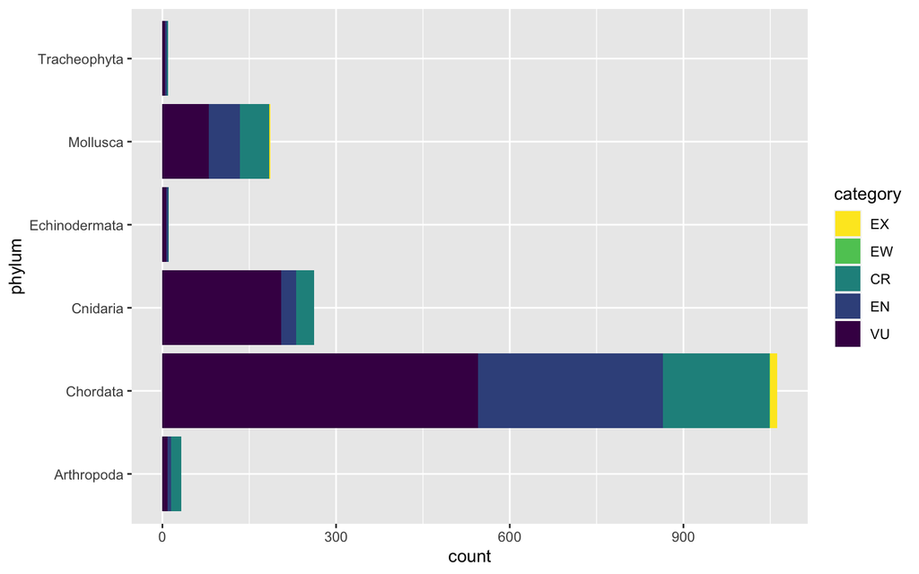

```r
ggplot(worms %>% filter(!is.na(category))) +
  geom_bar(aes(x = phylum, fill = category)) +
  coord_flip() +
  scale_fill_viridis_d(direction = -1)
```

## Marine World Heritage Sites statistics

In this section we will look at the diversity of fish and vulnerable species in each marine World Heritage site.

### Fetch spatial data

Spatial features for the marine World Heritage sites have been prepared in another repository, see https://github.com/iobis/mwhs-shapes.

```r
if (!file.exists("data/marine_world_heritage.gpkg")) {
  download.file("https://github.com/iobis/mwhs-shapes/blob/master/output/marine_world_heritage.gpkg?raw=true", "data/marine_world_heritage.gpkg")
}

shapes <- st_read("data/marine_world_heritage.gpkg")
```

### Process spatial data

For some sites, the GeoPackage has core as well as buffer areas. Merge the geometries by site.

```r
shapes_processed <- shapes %>%
  group_by(name) %>%
  summarize()
```

### Fetch occurrence data

Now retrieve data from OBIS by area. OBIS is queried by bounding box, but a point-in-polygon calculation is used to discard points outside the areas.

```r
occ_for_geom <- function(geom) {
  wkt <- st_as_text(st_as_sfc(st_bbox(geom)), digits = 6)
  message(wkt)
  occ <- occurrence(geometry = wkt, fields = c("decimalLongitude", "decimalLatitude", "date_year", "scientificName", "aphiaID", "dataset_id")) %>%
    st_as_sf(coords = c("decimalLongitude", "decimalLatitude"), crs = 4326)
  occ_filtered <- occ %>%
    filter(st_intersects(geometry, geom, sparse = FALSE)) %>%
    as_tibble() %>%
    select(-geometry)
  return(occ_filtered)
}

sf_use_s2(FALSE)

if (!file.exists("data/occurrence.Rdata")) {
  occs <- map(shapes_processed$geom, occ_for_geom)
  for (i in 1:nrow(shapes_processed)) {
    occs[[i]]$name <- shapes_processed$name[i]
  }
  occ <- bind_rows(occs)
  save(occ, file = "data/occurrence.Rdata")
} else {
  load("data/occurrence.Rdata")
}

occ <- occ %>%
  inner_join(worms %>% select(phylum, class, order, family, genus, is_fish, is_coral, aphiaID, category, sequences), by = "aphiaID") %>%
  mutate(
    aphia_fish = ifelse(is_fish == TRUE, aphiaID, NA),
    aphia_vulnerable = ifelse(!is.na(category), aphiaID, NA),
    aphia_vulnerable_fish = ifelse(is_fish == TRUE & !is.na(category), aphiaID, NA),
    aphia_barcode_fish = ifelse(is_fish == TRUE & sequences > 0, aphiaID, NA),
  )
```

### Calculate statistics

```r
occ %>%
  summarize(
    records = n(),
    species = length(unique(aphiaID)),
    fish = length(unique(aphia_fish)),
    vulnerable = length(unique(aphia_vulnerable)),
    vulnerable_fish = length(unique(aphia_vulnerable_fish)),
    barcode_fish =  length(unique(aphia_barcode_fish))
  ) %>%
  kable(format.args = list(big.mark = ","))
```

| records | species | fish | vulnerable | vulnerable_fish | barcode_fish |
| --- | --- | --- | --- | --- | --- |
| 3,588,181 | 28,258 | 6,700 | 550 | 298 | 271 |

```r
site_stats <- occ %>%
  group_by(name) %>%
  summarize(
    records = n(),
    species = length(unique(aphiaID)),
    fish = length(unique(aphia_fish)),
    vulnerable = length(unique(aphia_vulnerable)),
    vulnerable_fish = length(unique(aphia_vulnerable_fish)),
    barcode_fish =  length(unique(aphia_barcode_fish))
  )

xlsx::write.xlsx(site_stats, file = "output/sites.xlsx")

site_stats %>%
  kable(format.args = list(big.mark = ","))
```

| name | records | species | fish | vulnerable | vulnerable_fish | barcode_fish |
| --- | --- | --- | --- | --- | --- | --- |
| Aldabra Atoll | 2,946 | 1,038 | 498 | 81 | 9 | 7 |
| Archipiélago de Revillagigedo | 9,021 | 469 | 376 | 62 | 49 | 25 |
| Area de Conservación Guanacaste | 1,135 | 359 | 345 | 15 | 12 | 8 |
| Banc d’Arguin National Park | 1,224 | 44 | 23 | 5 | 4 | 3 |
| Belize Barrier Reef Reserve System | 8,790 | 1,082 | 345 | 50 | 28 | 11 |
| Brazilian Atlantic Islands: Fernando de Noronha and Atol das Rocas Reserves | 25,893 | 542 | 165 | 15 | 11 | 11 |
| Cocos Island National Park | 2,429 | 531 | 408 | 55 | 50 | 29 |
| Coiba National Park and its Special Zone of Marine Protection | 2,522 | 593 | 439 | 30 | 26 | 16 |
| East Rennell | 27 | 9 | 6 | 1 | 1 | 1 |
| Everglades National Park | 60,414 | 935 | 285 | 30 | 19 | 10 |
| French Austral Lands and Seas | 165,351 | 1,458 | 277 | 25 | 6 | 18 |
| Galápagos Islands | 60,148 | 1,628 | 729 | 89 | 67 | 36 |
| Gough and Inaccessible Islands | 2,497 | 198 | 46 | 12 | 5 | 6 |
| Great Barrier Reef | 1,309,086 | 12,915 | 2,834 | 238 | 93 | 127 |
| Gulf of Porto: Calanche of Piana, Gulf of Girolata, Scandola Reserve | 113 | 21 | 2 | 5 | 1 | 1 |
| Ha Long Bay | 1,967 | 326 | 318 | 8 | 8 | 4 |
| Heard and McDonald Islands | 38,615 | 257 | 29 | 10 | 1 | 4 |
| High Coast / Kvarken Archipelago | 16,510 | 128 | 19 | 2 | 2 | 1 |
| Ibiza, Biodiversity and Culture | 72 | 35 | 14 | 2 | 1 | 2 |
| iSimangaliso Wetland Park | 25,036 | 2,294 | 1,100 | 88 | 67 | 57 |
| Islands and Protected Areas of the Gulf of California | 17,184 | 1,308 | 772 | 76 | 56 | 55 |
| Kluane / Wrangell-St Elias / Glacier Bay / Tatshenshini-Alsek | 965 | 122 | 91 | 8 | 2 | 5 |
| Komodo National Park | 682 | 363 | 217 | 12 | 10 | 8 |
| Lagoons of New Caledonia: Reef Diversity and Associated Ecosystems | 30,368 | 4,539 | 871 | 44 | 16 | 13 |
| Lord Howe Island Group | 39,412 | 1,774 | 484 | 45 | 15 | 18 |
| Macquarie Island | 89,036 | 652 | 98 | 14 | 1 | 2 |
| Malpelo Fauna and Flora Sanctuary | 8,421 | 395 | 269 | 50 | 38 | 24 |
| Natural System of Wrangel Island Reserve | 295 | 63 | 11 | 7 | 1 | 1 |
| New Zealand Sub-Antarctic Islands | 10,681 | 1,283 | 78 | 28 | 8 | 16 |
| Ningaloo Coast | 346,971 | 3,195 | 927 | 104 | 52 | 64 |
| Ogasawara Islands | 444 | 239 | 120 | 19 | 5 | 4 |
| Papahānaumokuākea | 271,733 | 1,739 | 586 | 43 | 18 | 15 |
| Pennsula Valds | 4,479 | 215 | 6 | 8 | 1 | 1 |
| Phoenix Islands Protected Area | 3,337 | 670 | 362 | 10 | 6 | 3 |
| Puerto Princesa Subterranean River National Park | 1 | 1 | 1 | 1 | 1 | 1 |
| Rock Islands Southern Lagoon | 22,417 | 2,232 | 1,062 | 53 | 16 | 7 |
| Sanganeb Marine National Park and Dungonab Bay - Mukkawar Island Marine National Park | 643 | 150 | 9 | 9 | 2 | 2 |
| Shark Bay, Western Australia | 13,290 | 1,347 | 538 | 49 | 17 | 32 |
| Shiretoko | 291 | 59 | 57 | 2 | 1 | 1 |
| Sian Ka’an | 2,513 | 226 | 110 | 30 | 9 | 11 |
| Socotra Archipelago | 4,325 | 595 | 119 | 21 | 2 | 1 |
| St Kilda | 7,674 | 394 | 31 | 9 | 3 | 3 |
| Surtsey | 7 | 3 | 1 | 3 | 1 | 1 |
| The Wadden Sea | 977,943 | 749 | 101 | 18 | 12 | 10 |
| Tubbataha Reefs Natural Park | 209 | 63 | 9 | 9 | 5 | 5 |
| Ujung Kulon National Park | 3 | 2 | 1 | 2 | 1 | 1 |
| West Norwegian Fjords – Geirangerfjord and Nærøyfjord | 17 | 8 | 1 | 2 | 1 | 1 |
| Whale Sanctuary of El Vizcaino | 1,044 | 168 | 124 | 12 | 11 | 18 |

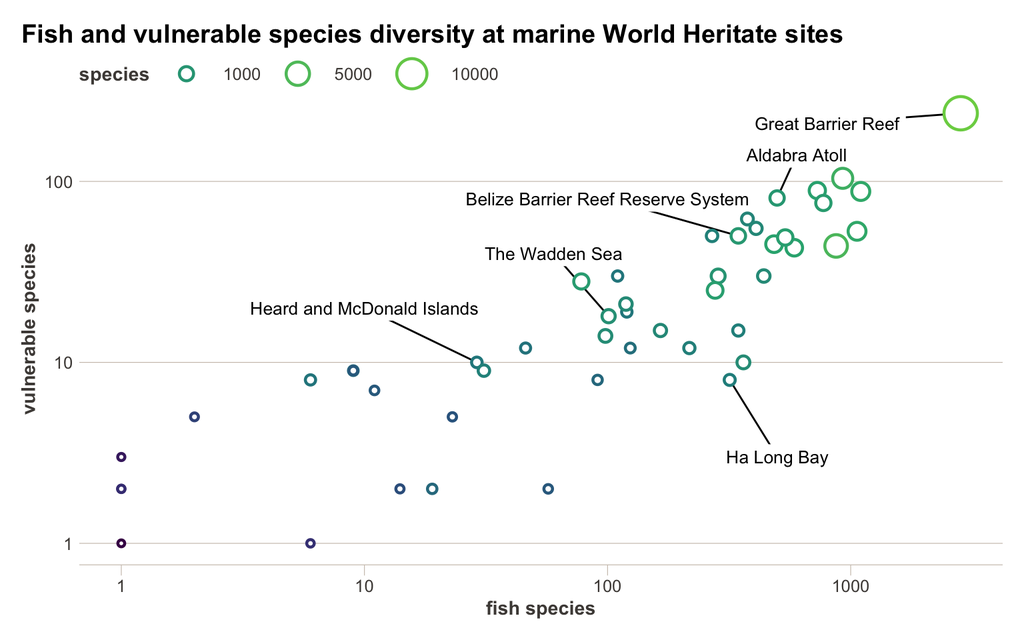

```r
subset <- site_stats %>%
  filter(name %in% c("Great Barrier Reef", "Belize Barrier Reef Reserve System", "Ha Long Bay", "The Wadden Sea", "Heard and McDonald Islands", "Aldabra Atoll")) %>%
  arrange(name)

subset$x <- c(600, 100, 800, 500, 10, 60)
subset$y <- c(140, 80, 210, 3, 20, 40)

ggplot() +
  geom_segment(subset, mapping = aes(x = x, y = y, xend = fish, yend = vulnerable)) +
  geom_label(subset, mapping = aes(x = x, y = y, label = name), size = 3.5, label.size = 0) +
  geom_point(site_stats, mapping = aes(x = fish, y = vulnerable, size = species, color = species), shape = 21, stroke = 1.2, fill = "white") +
  scale_x_continuous(trans = "log10") +
  scale_y_continuous(trans = "log10") +
  scale_size(range = c(1, 8), breaks = c(1000, 5000, 10000)) +
  scale_color_viridis_c(end = 0.8, trans = "log10", breaks = c(1000, 5000, 10000)) +
  guides(color = guide_legend(), size = guide_legend()) +
  xlab("fish species") + ylab("vulnerable species") +
  ft_theme() +
  ggtitle("Fish and vulnerable species diversity at marine World Heritate sites")
```

```r
ggsave("output/sites.png", width = 10, height = 6, dpi = 600)
```

### Species lists by site

```r
species_lists <- occ %>%
  group_by(name, scientificName, aphiaID, phylum, class, order, family, genus, is_fish, is_coral, category, sequences) %>%
  summarize() %>%
  select(site = name, scientificName, aphiaID, phylum, class, order, family, genus, is_fish, is_coral, iucn_category = category, bold_sequences = sequences) %>%
  arrange(site, phylum, class, order, family, scientificName) %>%
  ungroup()

write.csv(species_lists, file = "output/species_lists.csv", row.names = FALSE, na = "")
xlsx::write.xlsx(as.data.frame(species_lists), file = "output/species_lists.xlsx", showNA = FALSE, row.names = FALSE)
xlsx::write.xlsx(as.data.frame(species_lists %>% filter(is_fish)), file = "output/species_lists_fish.xlsx", showNA = FALSE, row.names = FALSE)
```